# Covid-19 infección en Ecuador. Modelos matemáticos y predicciones

# Nuevos Datos:

```python
# Actualizar los datos (URL)

url = 'https://covid.ourworldindata.org/data/ecdc/total_cases.csv'

df1 = pd.read_csv(url)
df1.head()
```

|  | date | World | Afghanistan | Albania | Algeria | Andorra | Angola | Anguilla | Antigua and Barbuda | Argentina | ... | United Kingdom | United States | United States Virgin Islands | Uruguay | Uzbekistan | Vatican | Venezuela | Vietnam | Zambia | Zimbabwe |
| --- | --- | --- | --- | --- | --- | --- | --- | --- | --- | --- | --- | --- | --- | --- | --- | --- | --- | --- | --- | --- | --- |
| 0 | 2019-12-31 | 27 | 0.0 | NaN | 0.0 | NaN | NaN | NaN | NaN | NaN | ... | 0 | 0 | NaN | NaN | NaN | NaN | NaN | 0.0 | NaN | NaN |
| 1 | 2020-01-01 | 27 | 0.0 | NaN | 0.0 | NaN | NaN | NaN | NaN | NaN | ... | 0 | 0 | NaN | NaN | NaN | NaN | NaN | 0.0 | NaN | NaN |
| 2 | 2020-01-02 | 27 | 0.0 | NaN | 0.0 | NaN | NaN | NaN | NaN | NaN | ... | 0 | 0 | NaN | NaN | NaN | NaN | NaN | 0.0 | NaN | NaN |
| 3 | 2020-01-03 | 44 | 0.0 | NaN | 0.0 | NaN | NaN | NaN | NaN | NaN | ... | 0 | 0 | NaN | NaN | NaN | NaN | NaN | 0.0 | NaN | NaN |
| 4 | 2020-01-04 | 44 | 0.0 | NaN | 0.0 | NaN | NaN | NaN | NaN | NaN | ... | 0 | 0 | NaN | NaN | NaN | NaN | NaN | 0.0 | NaN | NaN |

5 rows × 207 columns

### Seleccionar datos de la columan Ecuador

```python
df1=df1.loc[:, ['date','Ecuador']]
#df1=df1.loc[:,'date']
df1
```

|  | date | Ecuador |
| --- | --- | --- |
| 0 | 2019-12-31 | 0.0 |
| 1 | 2020-01-01 | 0.0 |
| 2 | 2020-01-02 | 0.0 |
| 3 | 2020-01-03 | 0.0 |
| 4 | 2020-01-04 | 0.0 |
| 5 | 2020-01-05 | 0.0 |
| 6 | 2020-01-06 | 0.0 |
| 7 | 2020-01-07 | 0.0 |
| 8 | 2020-01-08 | 0.0 |
| 9 | 2020-01-09 | 0.0 |
| 10 | 2020-01-10 | 0.0 |
| 11 | 2020-01-11 | 0.0 |
| 12 | 2020-01-12 | 0.0 |
| 13 | 2020-01-13 | 0.0 |
| 14 | 2020-01-14 | 0.0 |
| 15 | 2020-01-15 | 0.0 |
| 16 | 2020-01-16 | 0.0 |
| 17 | 2020-01-17 | 0.0 |
| 18 | 2020-01-18 | 0.0 |
| 19 | 2020-01-19 | 0.0 |
| 20 | 2020-01-20 | 0.0 |
| 21 | 2020-01-21 | 0.0 |
| 22 | 2020-01-22 | 0.0 |
| 23 | 2020-01-23 | 0.0 |
| 24 | 2020-01-24 | 0.0 |
| 25 | 2020-01-25 | 0.0 |
| 26 | 2020-01-26 | 0.0 |
| 27 | 2020-01-27 | 0.0 |
| 28 | 2020-01-28 | 0.0 |
| 29 | 2020-01-29 | 0.0 |
| ... | ... | ... |
| 68 | 2020-03-08 | NaN |
| 69 | 2020-03-09 | 14.0 |
| 70 | 2020-03-10 | 15.0 |
| 71 | 2020-03-11 | 17.0 |
| 72 | 2020-03-12 | NaN |
| 73 | 2020-03-13 | NaN |
| 74 | 2020-03-14 | 23.0 |
| 75 | 2020-03-15 | 28.0 |
| 76 | 2020-03-16 | 37.0 |
| 77 | 2020-03-17 | 58.0 |
| 78 | 2020-03-18 | 111.0 |
| 79 | 2020-03-19 | 168.0 |
| 80 | 2020-03-20 | 199.0 |
| 81 | 2020-03-21 | 426.0 |
| 82 | 2020-03-22 | 532.0 |
| 83 | 2020-03-23 | 789.0 |
| 84 | 2020-03-24 | 981.0 |
| 85 | 2020-03-25 | 1082.0 |
| 86 | 2020-03-26 | 1211.0 |
| 87 | 2020-03-27 | 1403.0 |
| 88 | 2020-03-28 | 1627.0 |
| 89 | 2020-03-29 | 1835.0 |
| 90 | 2020-03-30 | 1890.0 |
| 91 | 2020-03-31 | 1966.0 |
| 92 | 2020-04-01 | 2302.0 |
| 93 | 2020-04-02 | 2758.0 |
| 94 | 2020-04-03 | 3163.0 |
| 95 | 2020-04-04 | 3368.0 |
| 96 | 2020-04-05 | 3465.0 |
| 97 | 2020-04-06 | 3646.0 |

98 rows × 2 columns

## dias de contagia explesado en fecha

```python
FMT = '%Y-%m-%d'
date = df1['date']
df1['date'] = date.map(lambda x : (datetime.strptime(x, FMT) - datetime.strptime("2020-01-01", FMT)).days)
df1
```

|  | date | Ecuador |
| --- | --- | --- |
| 0 | -1 | 0.0 |
| 1 | 0 | 0.0 |
| 2 | 1 | 0.0 |
| 3 | 2 | 0.0 |
| 4 | 3 | 0.0 |
| 5 | 4 | 0.0 |
| 6 | 5 | 0.0 |
| 7 | 6 | 0.0 |
| 8 | 7 | 0.0 |
| 9 | 8 | 0.0 |
| 10 | 9 | 0.0 |
| 11 | 10 | 0.0 |
| 12 | 11 | 0.0 |
| 13 | 12 | 0.0 |
| 14 | 13 | 0.0 |
| 15 | 14 | 0.0 |
| 16 | 15 | 0.0 |
| 17 | 16 | 0.0 |
| 18 | 17 | 0.0 |
| 19 | 18 | 0.0 |
| 20 | 19 | 0.0 |
| 21 | 20 | 0.0 |
| 22 | 21 | 0.0 |
| 23 | 22 | 0.0 |
| 24 | 23 | 0.0 |
| 25 | 24 | 0.0 |
| 26 | 25 | 0.0 |
| 27 | 26 | 0.0 |
| 28 | 27 | 0.0 |
| 29 | 28 | 0.0 |
| ... | ... | ... |
| 68 | 67 | NaN |
| 69 | 68 | 14.0 |
| 70 | 69 | 15.0 |
| 71 | 70 | 17.0 |
| 72 | 71 | NaN |
| 73 | 72 | NaN |
| 74 | 73 | 23.0 |
| 75 | 74 | 28.0 |
| 76 | 75 | 37.0 |
| 77 | 76 | 58.0 |
| 78 | 77 | 111.0 |
| 79 | 78 | 168.0 |
| 80 | 79 | 199.0 |
| 81 | 80 | 426.0 |
| 82 | 81 | 532.0 |
| 83 | 82 | 789.0 |
| 84 | 83 | 981.0 |
| 85 | 84 | 1082.0 |
| 86 | 85 | 1211.0 |
| 87 | 86 | 1403.0 |
| 88 | 87 | 1627.0 |
| 89 | 88 | 1835.0 |
| 90 | 89 | 1890.0 |
| 91 | 90 | 1966.0 |
| 92 | 91 | 2302.0 |
| 93 | 92 | 2758.0 |
| 94 | 93 | 3163.0 |
| 95 | 94 | 3368.0 |
| 96 | 95 | 3465.0 |
| 97 | 96 | 3646.0 |

98 rows × 2 columns

## filtro para mostrar solo los dias que tiene casos positivos en ecuador

```python
df2 = df1[df1['Ecuador'] >= 1]

print(df2)
```

```
    date  Ecuador
61    60      1.0
62    61      6.0
63    62      7.0
65    64     10.0
66    65     13.0
69    68     14.0
70    69     15.0
71    70     17.0
74    73     23.0
75    74     28.0
76    75     37.0
77    76     58.0
78    77    111.0
79    78    168.0
```

[output cut: 18 more lines]

## Grafica de los casos Ecuador

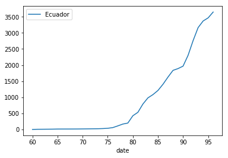

```python
df2.plot(x ='date', y='Ecuador')
```

# Regresion lineal

### crear lista de datos de fecha y contagiados.

```python
x1 = list(df2.iloc [:, 0]) # Fecha

y1= list(df2.iloc [:, 1]) # Numero de casos
print('x',x1)
print('y',y1)

regr = linear_model.LinearRegression()

# Entrenamos nuestro modelo
regr.fit(np.array(x1).reshape(-1, 1) ,y1)

# Veamos los coeficienetes obtenidos, En nuestro caso, serán la Tangente
print('Coefficients: \n', regr.coef_)
# Este es el valor donde corta el eje Y (en X=0)
print('Independent term: \n', regr.intercept_)
# Error Cuadrado Medio
```

```
x [60, 61, 62, 64, 65, 68, 69, 70, 73, 74, 75, 76, 77, 78, 79, 80, 81, 82, 83, 84, 85, 86, 87, 88, 89, 90, 91, 92, 93, 94, 95, 96]
y [1.0, 6.0, 7.0, 10.0, 13.0, 14.0, 15.0, 17.0, 23.0, 28.0, 37.0, 58.0, 111.0, 168.0, 199.0, 426.0, 532.0, 789.0, 981.0, 1082.0, 1211.0, 1403.0, 1627.0, 1835.0, 1890.0, 1966.0, 2302.0, 2758.0, 3163.0, 3368.0, 3465.0, 3646.0]
Coefficients:
 [99.48247423]
Independent term:
 -6882.214432989691
```

prediccion al dia 100

```python
y_prediccion = regr.predict([[100]])
print(int(y_prediccion))
```

```
3066
```

```
[59 60 61 62 63 64 65 66 67 68 69 70 71 72 73 74 75 76 77 78 79 80 81 82
 83 84 85 86 87 88 89 90 91 92 93 94 95 96 97 98 99]
```

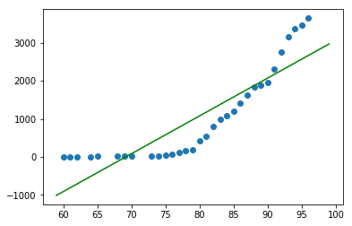

```python
#Graficar
plt.scatter(x1, y1)
x_real = np.array(range(59, 100))
print(x_real)
plt.plot(x_real, regr.predict(x_real.reshape(-1, 1)), color='green')
plt.show()
```

## Modelo exponencial

Mientras que el modelo logístico describe un crecimiento de infección que se detendrá en el futuro, el modelo exponencial describe un crecimiento de infección imparable . Por ejemplo, si un paciente infecta a 2 pacientes por día, después de 1 día tendremos 2 infecciones, 4 después de 2 días, 8 después de 3 y así sucesivamente.

```
32
```

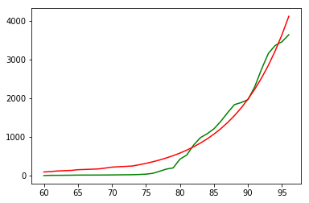

```python
# print(x1)#resolucion
# x = np.array(x1, dtype=float) #transform your data in a numpy array of floats
# y = np.array(y1, dtype=float)


# print(x)
# plt.plot(x, y, 'ro',label="Original Data")

# def funceEx(x, c,k):
#         return  (c*np.exp(k*x))
# popt, pcov = curve_fit(funce, x1, y1)



# plt.title('exponencial',fontsize=16)

# plt.plot(x, funceEx(x, *popt), label="Fitted Curve") #same as line above \/



# plt.legend(loc='upper left')
#plt.show()

casos=df2.iloc[:,1]
print(len(casos))
fecha=np.arange(1,len(casos)+1,1)
#fecha=np.arange(60,92,1)
#fecha= np.array(x1, dtype=float)
#print(casos)
def funcEx(x,c,k):
    return (c*np.exp(k*x))
popt,pcov=curve_fit(funcEx,fecha,casos)
c=popt
k=pcov

plt.plot(x1,y1,color='green')
plt.plot(x1,funcEx(fecha,*popt),color="red")
plt.show()
```

proyeccion a 100 dias

```python
#ponemos el valor de 40  ya que nuestro algoritmo empieza en el valor de 0 y nuestro
#contagia es a partir del dia 60 si queremos saber el contagio al dia 100 se
#realiza 100-primer caso=40
print('proyeccion exponencial a 100 dias',funcEx(40,*popt),'personasl contagiadas')
```

```
proyeccion exponencial a 100 dias 10964.14691722823 personasl contagiadas
```

# Modelo polinomial

### Proyeccion para el dia 100

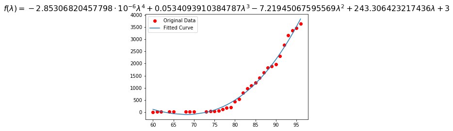

```python
import matplotlib.pyplot as plt
from scipy.optimize import curve_fit
import numpy as np
import sympy as sym







x = np.array(x1, dtype=float) #transform your data in a numpy array of floats
y = np.array(y1, dtype=float) #so the curve_fit can work

plt.plot(x1, y1, 'ro',label="Original Data")

#def func(x, a, b, c, d):
 #      return a*x**3 + b*x**2 +c*x + d
##orden 4
def func(x, a, b, c, d,e):
      return a*x**4 + b*x**3 +c*x**2 + d*x + 3

popt, pcov = curve_fit(func, x, y)



xs = sym.Symbol('\lambda')
tex = sym.latex(func(xs,*popt)).replace('$', '')
plt.title(r'$f(\lambda)= %s$' %(tex),fontsize=16)


plt.plot(x, func(x, *popt), label="Fitted Curve") #same as line above \/
#plt.plot(x, popt[0]*x**3 + popt[1]*x**2 + popt[2]*x + popt[3], label="Fitted Curve")

plt.legend(loc='upper left')
plt.show()
```

proyeccion

```python
print('proyeccion100:',func(100, *popt))
```

```
proyeccion100: 5263.219780207666
```

## Analisis

Respecto a las graficas podemos observar que el modelo que mas se ajusta a la proyeccion del covid-19 es el modelo polinomial de cuarto orden, para poder realizar este trabajo se necesito repasar conceptos basicos de los modelos exponencial y el modelo polinomial, una vez endendido podemos crear nuestra funcion a la cual se le indica el numero de dia y se ejecuat la funcion con los datos que tenemos para ajustar la grafica a nuestro conjunto de datos en los dos metodos finales nuestra funcioin depende de los datos para asi determinar nuestras constantes, se puede decir que entrenamos nuestra funcion para que se proyecte a medida de nuestros datos.

## Conclusiones

las funcines exponenciales y de orden 4 se apegan en la gran mayoria a nuestra cifras de evolucion del covid siendo una proyeccion alarmante pero segun las cifras que podemos contastar el nuvel de contagio es de 100 a 200 por dia en la actualidad por lo que podemos que la proyeccion paa el dia 100 puede ser mejor la polinomial que al dia 100 nos indica que pueden llegar a ser 5263 contagiados

## Criterio personal (politico, economico y social de la situacion)

En la parte Economica afecta globalmente en todo debido a que no permite el flujo de dinero por lo que causa perdidas a las personas que no se puede laborar en estos momentos y las deudas siguen y si no existe deudas el poco dinero existente es con el que se debe sobrevivir por ahora y luego solventar deudas que todo esto genera

En la parte social el covid nos obliga a quedarnos en casa por lo que nos permite tener una vision mas pausada de todo a nuestro alrededor ya que en nuestro alrededor todo se mueve muy rapido y esto nos obliga a quedarnos en casa y tener que compartir mas en famiulia emplear ese tiempo en comprendeer todo lo que sucede